# Bus Ridership Prediction in Austin, TX

Hanyong Xu, Jia Yuan, Yibing Zheng

12/2019

# 1. Introduction

## Background

Cap Remap comes from a 10-year transit plan: Connections 2025. It aims to adjust the transit network according to internal analysis about what works the best and community outreach. It also aims to improve the east-west connection.

Passengers can buy their passes on the CapMetro app directly. The new network will cause more transfers to passengers but overall less waiting time. A single ride pass is $1.25. For a Day-Pass, it is $2.5 which allows a passenger to ride for unlimited times in 24 hours. They also have options for 7-day passes or monthly pass.

## Overview

- More frequent, more reliable and better connected
- Triple the number of bus routes that operate every 15min
- Make sure the frequency meets the need on weekends
- Link to [High-Frequency Service Map](https://capmetro.org/uploadedFiles/New2016/Plan_Your_Trip/Schedules_and_Maps/high-frequency-system-map.pdf): shows the routes operate every 15min

# Exploratory Analysis

```r
library(tidyverse)
library(sf)
library(QuantPsyc)
library(RSocrata)
library(viridis)
library(caret)
library(spatstat)
library(spdep)
library(FNN)
library(grid)
library(gridExtra)
library(knitr)
library(kableExtra)
library(tidycensus)
library(nnet)
library(reshape2)
library(class)
library(MASS)
library(dplyr)
library(tidyr)
library(lubridate)
library(plotly)
library(ggmap)
library(data.table)
library(gganimate)
library(corrplot)
library(stargazer)
library(tigris)
library(ckanr)
library(ggplot2)
```

```r
mapTheme <- function(base_size = 10) {
  theme(
    text = element_text(color = "black"),
    plot.title = element_text(size = 12,colour = "black"),
    plot.subtitle=element_text(face="italic"),
    plot.caption=element_text(hjust=0),
    axis.ticks = element_blank(),
    panel.background = element_blank(),
    axis.title = element_blank(),
    strip.background = element_rect(fill = "white", color = "white"),
    strip.text.x = element_text(size = 8),
    axis.text = element_blank(),
    axis.title.x = element_blank(),
    axis.title.y = element_blank(),
    panel.grid.minor = element_blank()
  )
}

plotTheme <- theme(
  plot.title =element_text(size=12),
  plot.subtitle = element_text(size=8),
  plot.caption = element_text(size = 6),
  axis.text.x = element_text(size = 10, angle = 45, hjust = 1),
  axis.text.y = element_text(size = 10),
  axis.title.y = element_text(size = 10),
  # Set the entire chart region to blank
  panel.background=element_blank(),
  plot.background=element_blank(),
  axis.ticks=element_blank())

q5 <- function(variable) {as.factor(ntile(variable, 5))}
qBr <- function(df, variable, rnd) {
  if (missing(rnd)) {
    as.character(quantile(round(df[[variable]],0),
                          c(.01,.2,.4,.6,.8), na.rm=T))
  } else if (rnd == FALSE | rnd == F) {
    as.character(formatC(quantile(df[[variable]]), digits = 3),
                          c(.01,.2,.4,.6,.8), na.rm=T)
  }
}

plotTheme <- function(base_size = 12) {
  theme(
    text = element_text( color = "black"),
    plot.title = element_text(size = 14,colour = "black"),
    plot.subtitle = element_text(face="italic"),
    plot.caption = element_text(hjust=0),
    axis.ticks = element_blank(),
    panel.background = element_blank(),
    panel.grid.major = element_line("grey80", size = 0.1),
    panel.grid.minor = element_blank(),
    #panel.border = element_rect(colour = "black", fill=NA, size=2),
    strip.background = element_rect(fill = "grey80", color = "white"),
    strip.text = element_text(size=12),
    axis.title = element_text(size=12),
    axis.text = element_text(size=10),
    plot.background = element_blank(),
    legend.background = element_blank(),
    legend.title = element_text(colour = "black", face = "italic"),
    legend.text = element_text(colour = "black", face = "italic"),
    strip.text.x = element_text(size = 14)
  )
}
nn_function <- function(measureFrom,measureTo,k) {

  nn <-
    FNN::get.knnx(measureTo, measureFrom, k)$nn.dist

  output <-
    as.data.frame(nn) %>%
    rownames_to_column(var = "thisPoint") %>%
    gather(points, point_distance, V1:ncol(.)) %>%
    arrange(as.numeric(thisPoint)) %>%
    group_by(thisPoint) %>%
    summarize(pointDistance = mean(point_distance)) %>%
    arrange(as.numeric(thisPoint)) %>%
    dplyr::select(-thisPoint)

  return(output)
}
```

## Ridership Overall Trend Using the Aggregate Data

Charts about stop-level ridership change before and after CapRemap

```r
data <- read.csv('C:/Users/HanyongXu/Documents/Me/grad/Spring_2020/MUSA801/Data/MUSA Data - Stop Ridership Aggregated.csv')

data = data %>%
  rename(STOP_ID = ï..STOP_ID,)

table(data$YEAR_ID)
data.y18 <- data %>%
  subset(data$YEAR_ID == "2018")

max(data.y18$AVERAGE_ON)
```

```r
as.numeric(data$STOP_ID)

data.y18$MONTH_ID <- factor( data.y18$MONTH_ID, levels = c( "1", "2", "3", "4", "5", "6", "7", "8", "9", "10", "11", "12") )
data.y.1 <- data.y18 %>%
  subset(data.y18$STOP_ID <= 1050 & data.y18$AVERAGE_ON <= 30)

summary(data.y18$AVERAGE_ON)
```

Import School District shapefile

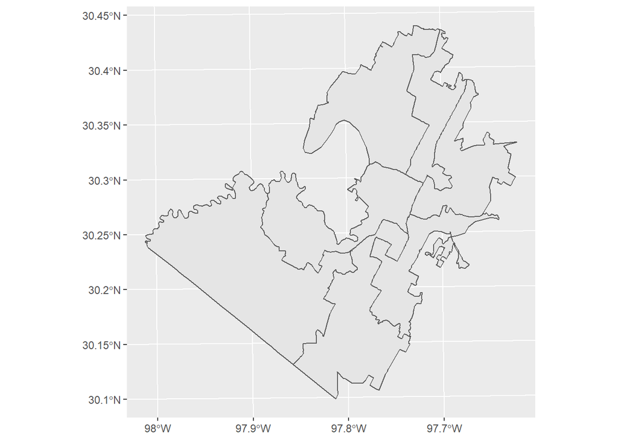

```r
TrusteeDist <-
  st_read("C:/Users/HanyongXu/Documents/Me/grad/Spring_2020/MUSA801/Data/Trustee_Boundaries/Trustee.shp")%>%
  st_transform(2278)

ggplot()+
  geom_sf(data = TrusteeDist)
```

Join stops and school districts

```r
data.sf <-
  data %>%
  st_as_sf(coords = c("LONGITUDE", "LATITUDE"), crs = 4326, agr = "constant") %>%
  st_transform(2278)

Austin.sf<-
  data.sf%>%
  st_join(dplyr::select(TrusteeDist,TRUSTEE))

data.y.Trustee18 <- Austin.sf %>%
  subset(Austin.sf$YEAR_ID == "2018")
```

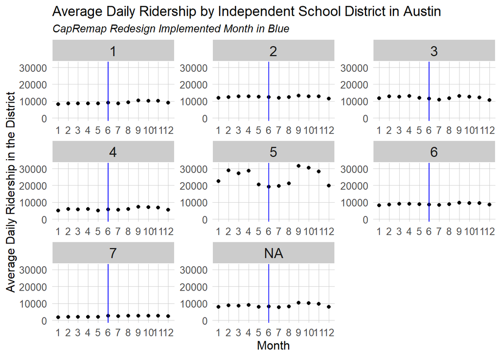

```r
data.y.Trustee18$MONTH_ID <- factor(data.y.Trustee18$MONTH_ID, levels = c( "1", "2", "3", "4", "5", "6", "7", "8", "9", "10", "11", "12") )

plot.Trustees <-
  as.data.frame(data.y.Trustee18) %>%
  group_by(TRUSTEE, MONTH_ID) %>%
   summarize(BOARD_Count = sum(AVERAGE_ON)) %>%
    ggplot(aes(MONTH_ID,BOARD_Count)) +
      geom_point() +
      plotTheme() +
      facet_wrap(~TRUSTEE, scales="free", ncol=3) +
      ylim(0,32000) +
      labs(title="Average Daily Ridership by Independent School District in Austin",
           subtitle="CapRemap Redesign Implemented Month in Blue", x="Month", y="Average Daily Ridership in the District")+
      geom_vline(xintercept = 6, color = "blue")

plot.Trustees
```

Making charts for Stops in TrusteeDistrict 1

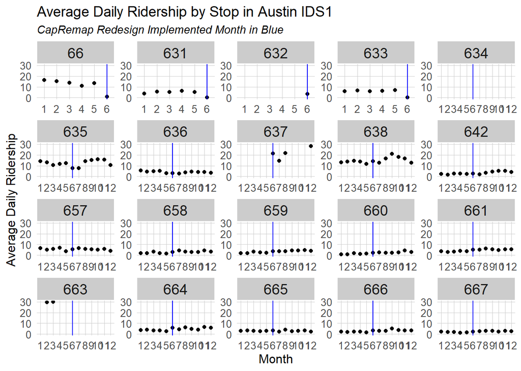

```r
data.y.18.S1 <- data.y.Trustee18 %>%
  subset(data.y.Trustee18$TRUSTEE == "1")
summary(data.y.18.S1$AVERAGE_ON)


plot.S1.0 <-
  as.data.frame(data.y.18.S1) %>%
  filter(STOP_ID <= 667) %>%
  group_by(STOP_ID) %>%
    ggplot(aes(x= MONTH_ID, y=AVERAGE_ON, group = 1)) +
      geom_point() +
      plotTheme() +
      facet_wrap(~STOP_ID, scales="free", ncol=5) +
      ylim(0,30) +
      labs(title="Average Daily Ridership by Stop in Austin IDS1",
           subtitle="CapRemap Redesign Implemented Month in Blue", x="Month", y="Average Daily Ridership")+
      geom_vline(xintercept = 6, color = "blue")

plot.S1.0
```

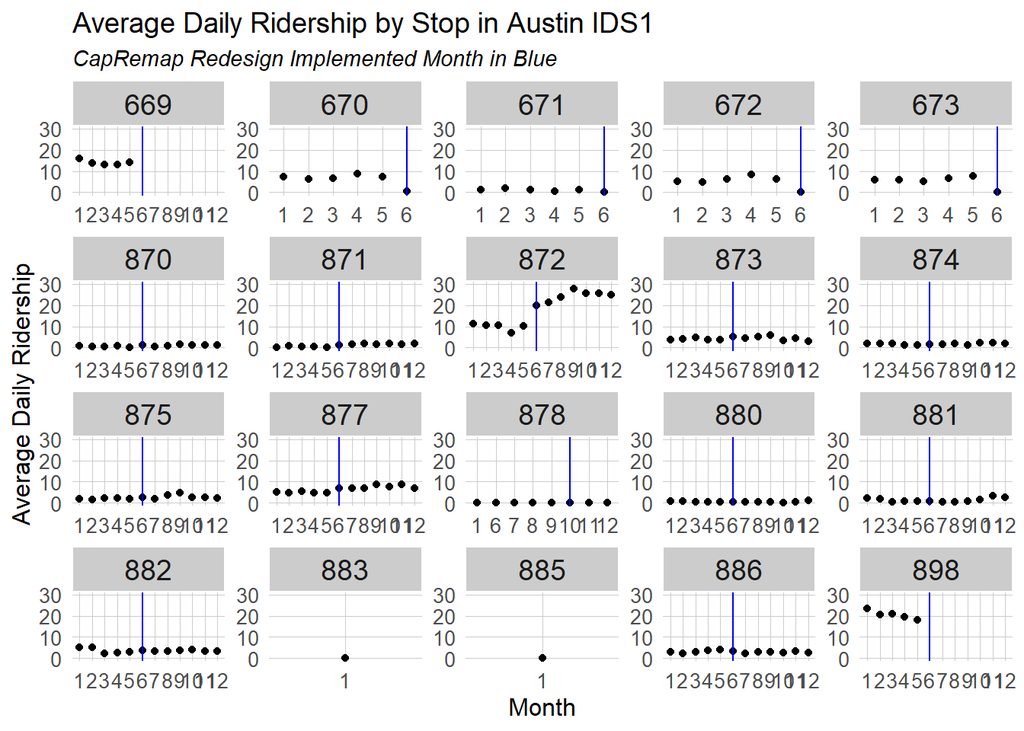

```r
plot.S1.1 <-
  as.data.frame(data.y.18.S1) %>%
  filter(STOP_ID > 667 &STOP_ID <= 898) %>%
  group_by(STOP_ID) %>%
    ggplot(aes(x= MONTH_ID, y=AVERAGE_ON, group = 1)) +
      geom_point() +
      plotTheme() +
      facet_wrap(~STOP_ID, scales="free", ncol=5) +
      ylim(0,30) +
      labs(title="Average Daily Ridership by Stop in Austin IDS1",
           subtitle="CapRemap Redesign Implemented Month in Blue", x="Month", y="Average Daily Ridership")+
      geom_vline(xintercept = 6, color = "blue")

plot.S1.1
```

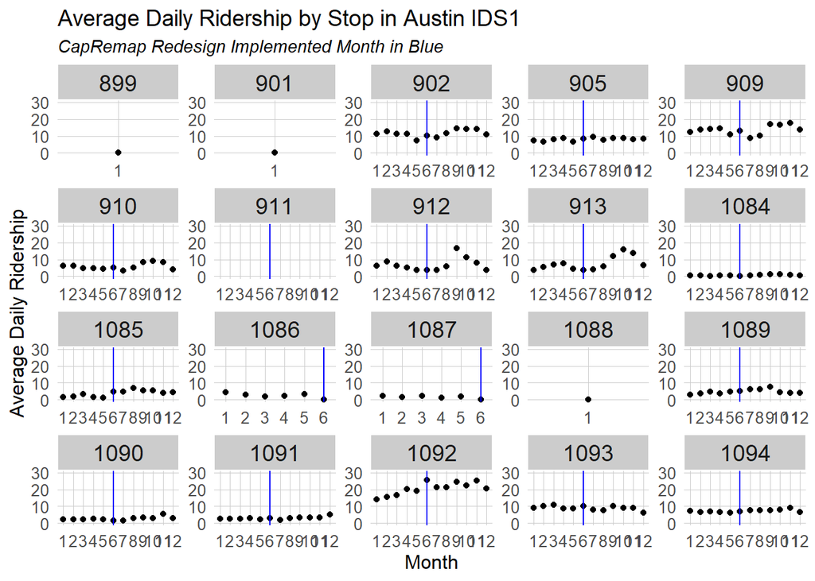

```r
plot.S1.1.1 <-
  as.data.frame(data.y.18.S1) %>%
  filter(STOP_ID > 898 &STOP_ID <= 1094) %>%
  group_by(STOP_ID) %>%
    ggplot(aes(x= MONTH_ID, y=AVERAGE_ON, group = 1)) +
      geom_point() +
      plotTheme() +
      facet_wrap(~STOP_ID, scales="free", ncol=5) +
      ylim(0,30) +
      labs(title="Average Daily Ridership by Stop in Austin IDS1",
           subtitle="CapRemap Redesign Implemented Month in Blue", x="Month", y="Average Daily Ridership")+
      geom_vline(xintercept = 6, color = "blue")

plot.S1.1.1
```

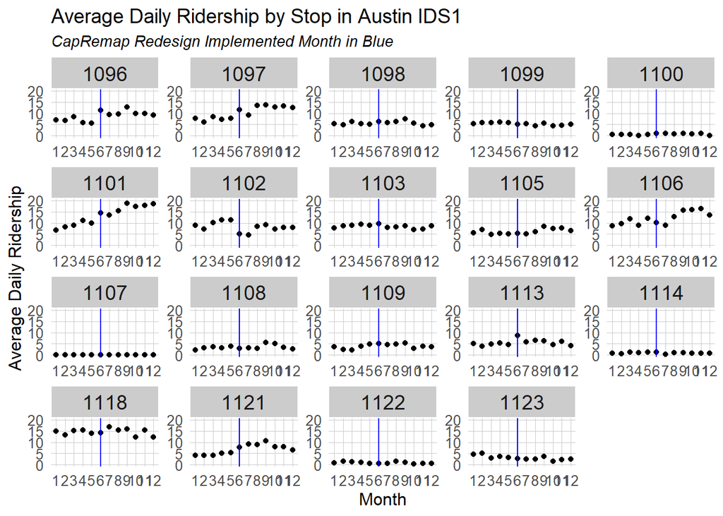

```r
plot.S1.2 <-
  as.data.frame(data.y.18.S1) %>%
  filter(STOP_ID > 1094 & STOP_ID <= 1123) %>%
  group_by(STOP_ID) %>%
    ggplot(aes(x= MONTH_ID, y=AVERAGE_ON, group = 1)) +
      geom_point() +
      plotTheme() +
      facet_wrap(~STOP_ID, scales="free", ncol=5) +
      ylim(0,20) +
      labs(title="Average Daily Ridership by Stop in Austin IDS1",
           subtitle="CapRemap Redesign Implemented Month in Blue", x="Month", y="Average Daily Ridership")+
      geom_vline(xintercept = 6, color = "blue")

plot.S1.2
```

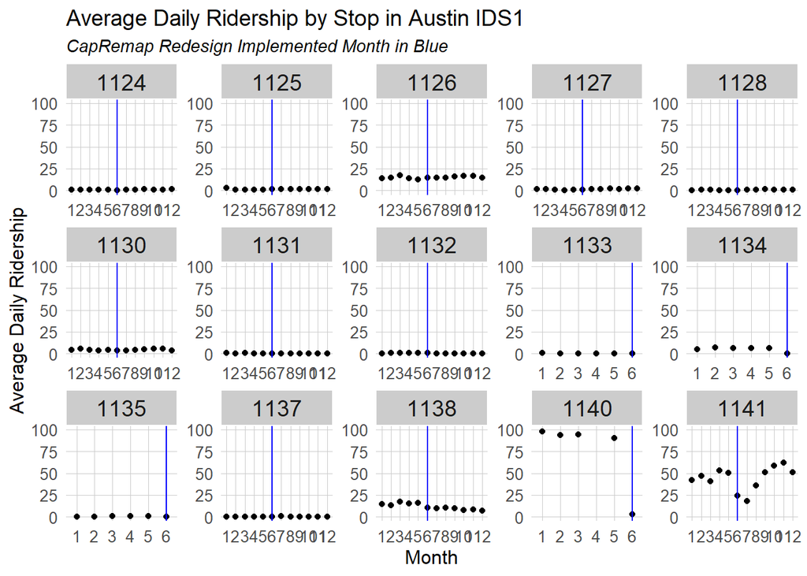

```r
plot.S1.3 <-
  as.data.frame(data.y.18.S1) %>%
  filter(STOP_ID > 1123 & STOP_ID <= 1141) %>%
  group_by(STOP_ID) %>%
    ggplot(aes(x= MONTH_ID, y=AVERAGE_ON, group = 1)) +
      geom_point() +
      plotTheme() +
      facet_wrap(~STOP_ID, scales="free", ncol=5) +
      ylim(0,100) +
      labs(title="Average Daily Ridership by Stop in Austin IDS1",
           subtitle="CapRemap Redesign Implemented Month in Blue", x="Month", y="Average Daily Ridership")+
      geom_vline(xintercept = 6, color = "blue")

plot.S1.3
```

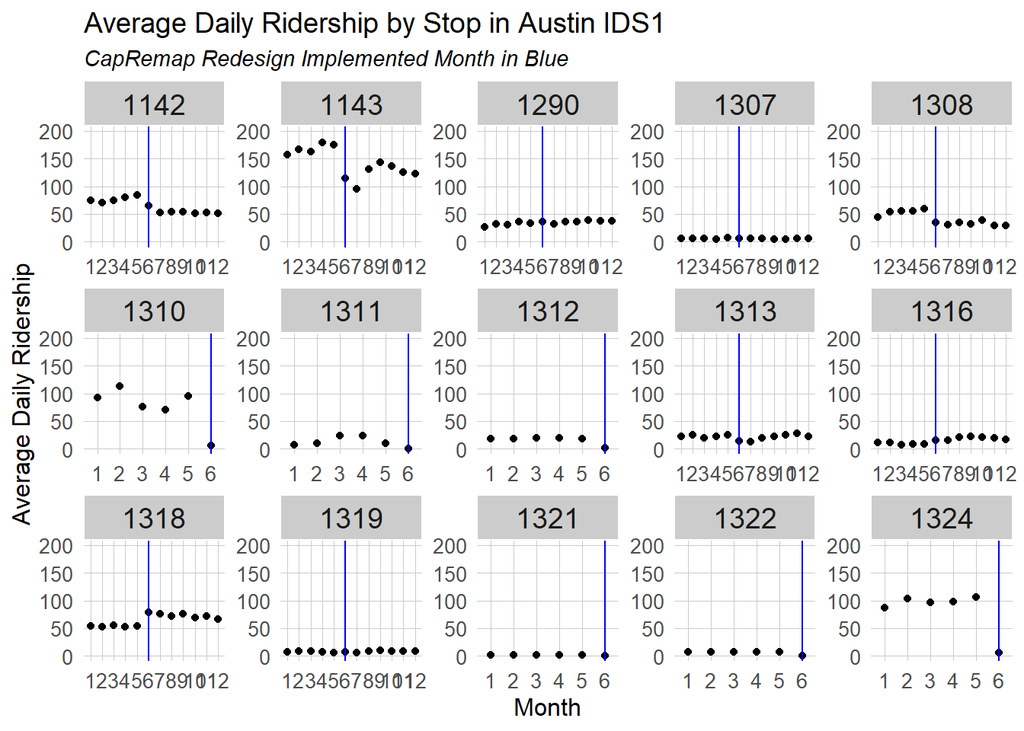

```r
plot.S1.4 <-
  as.data.frame(data.y.18.S1) %>%
  filter(STOP_ID > 1141 & STOP_ID <= 1324) %>%
  group_by(STOP_ID) %>%
    ggplot(aes(x= MONTH_ID, y=AVERAGE_ON, group = 1)) +
      geom_point() +
      plotTheme() +
      facet_wrap(~STOP_ID, scales="free", ncol=5) +
      ylim(0,200) +
      labs(title="Average Daily Ridership by Stop in Austin IDS1",
           subtitle="CapRemap Redesign Implemented Month in Blue", x="Month", y="Average Daily Ridership")+
      geom_vline(xintercept = 6, color = "blue")

plot.S1.4
```

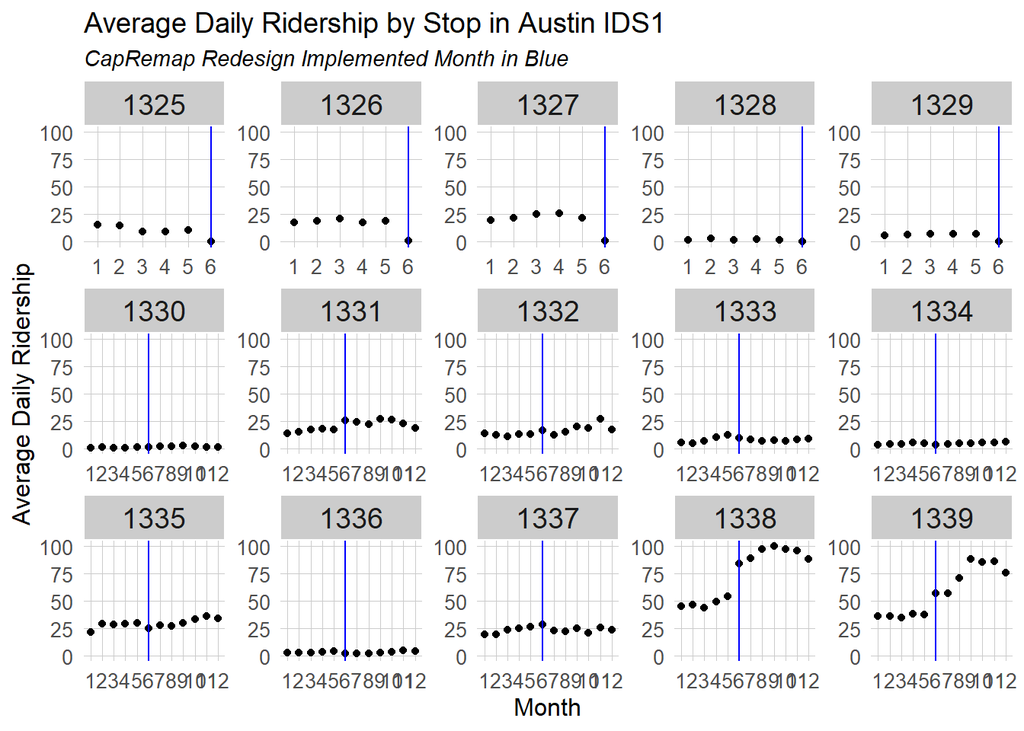

```r
plot.S1.5 <-
  as.data.frame(data.y.18.S1) %>%
  filter(STOP_ID > 1324 & STOP_ID <= 1339) %>%
  group_by(STOP_ID) %>%
    ggplot(aes(x= MONTH_ID, y=AVERAGE_ON, group = 1)) +
      geom_point() +
      plotTheme() +
      facet_wrap(~STOP_ID, scales="free", ncol=5) +
      ylim(0,101) +
      labs(title="Average Daily Ridership by Stop in Austin IDS1",
           subtitle="CapRemap Redesign Implemented Month in Blue", x="Month", y="Average Daily Ridership")+
      geom_vline(xintercept = 6, color = "blue")

plot.S1.5
```

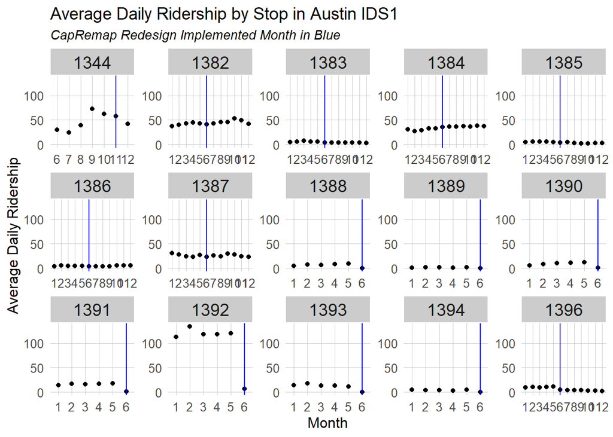

```r
plot.S1.6 <-
  as.data.frame(data.y.18.S1) %>%
  filter(STOP_ID > 1339 & STOP_ID <= 1396) %>%
  group_by(STOP_ID) %>%
    ggplot(aes(x= MONTH_ID, y=AVERAGE_ON, group = 1)) +
      geom_point() +
      plotTheme() +
      facet_wrap(~STOP_ID, scales="free", ncol=5) +
      ylim(0,135) +
      labs(title="Average Daily Ridership by Stop in Austin IDS1",
           subtitle="CapRemap Redesign Implemented Month in Blue", x="Month", y="Average Daily Ridership")+
      geom_vline(xintercept = 6, color = "blue")

plot.S1.6
```

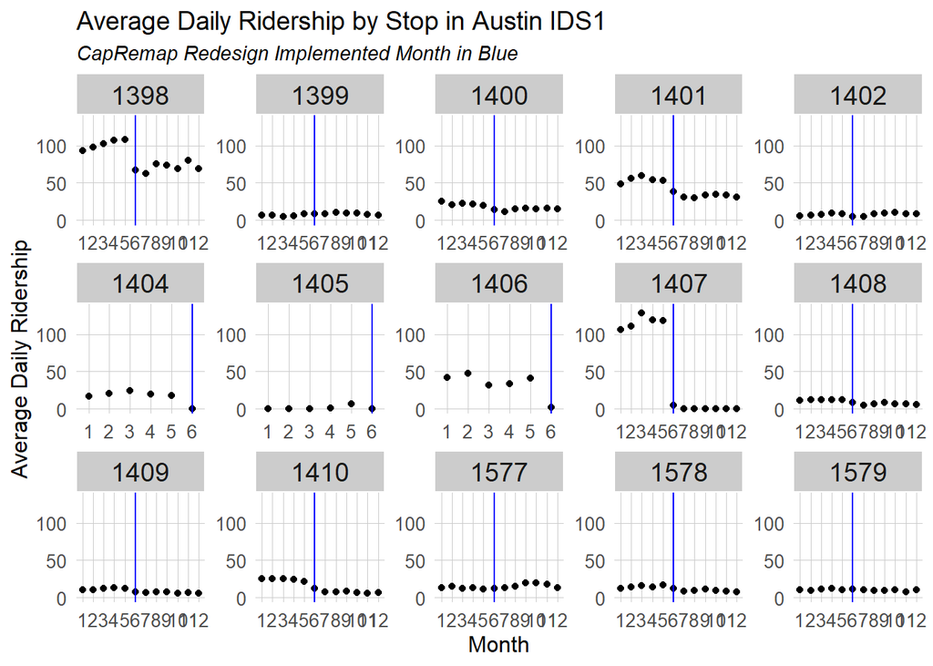

```r
plot.S1.7 <-
  as.data.frame(data.y.18.S1) %>%
  filter(STOP_ID > 1396 & STOP_ID <= 1579) %>%
  group_by(STOP_ID) %>%
    ggplot(aes(x= MONTH_ID, y=AVERAGE_ON, group = 1)) +
      geom_point() +
      plotTheme() +
      facet_wrap(~STOP_ID, scales="free", ncol=5) +
      ylim(0,135) +
      labs(title="Average Daily Ridership by Stop in Austin IDS1",
           subtitle="CapRemap Redesign Implemented Month in Blue", x="Month", y="Average Daily Ridership")+
      geom_vline(xintercept = 6, color = "blue")

plot.S1.7
```

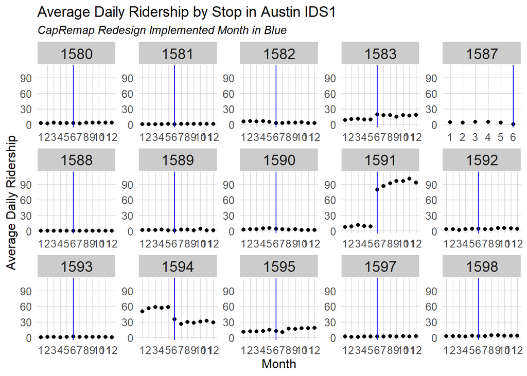

```r
plot.S1.8 <-
  as.data.frame(data.y.18.S1) %>%
  filter(STOP_ID > 1579 & STOP_ID <= 1598) %>%
  group_by(STOP_ID) %>%
    ggplot(aes(x= MONTH_ID, y=AVERAGE_ON, group = 1)) +
      geom_point() +
      plotTheme() +
      facet_wrap(~STOP_ID, scales="free", ncol=5) +
      ylim(0,110) +
      labs(title="Average Daily Ridership by Stop in Austin IDS1",
           subtitle="CapRemap Redesign Implemented Month in Blue", x="Month", y="Average Daily Ridership")+
      geom_vline(xintercept = 6, color = "blue")

plot.S1.8
```

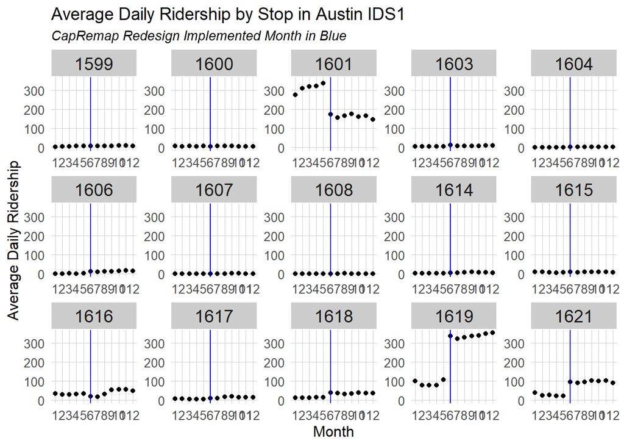

```r
plot.S1.9 <-
  as.data.frame(data.y.18.S1) %>%
  filter(STOP_ID > 1598 & STOP_ID <= 1621) %>%
  group_by(STOP_ID) %>%
    ggplot(aes(x= MONTH_ID, y=AVERAGE_ON, group = 1)) +
      geom_point() +
      plotTheme() +
      facet_wrap(~STOP_ID, scales="free", ncol=5) +
      ylim(0,355) +
      labs(title="Average Daily Ridership by Stop in Austin IDS1",
           subtitle="CapRemap Redesign Implemented Month in Blue", x="Month", y="Average Daily Ridership")+
      geom_vline(xintercept = 6, color = "blue")

plot.S1.9
```

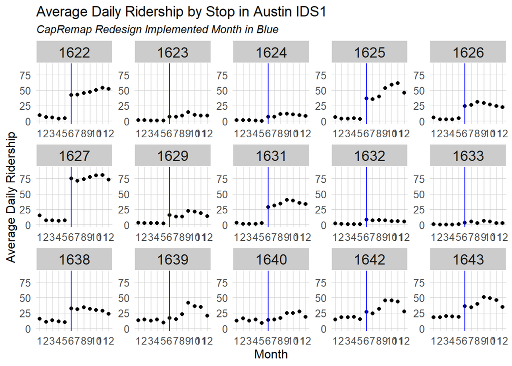

```r
plot.S1.10 <-
  as.data.frame(data.y.18.S1) %>%
  filter(STOP_ID > 1621 & STOP_ID <= 1643) %>%
  group_by(STOP_ID) %>%
    ggplot(aes(x= MONTH_ID, y=AVERAGE_ON, group = 1)) +
      geom_point() +
      plotTheme() +
      facet_wrap(~STOP_ID, scales="free", ncol=5) +
      ylim(0,90) +
      labs(title="Average Daily Ridership by Stop in Austin IDS1",
           subtitle="CapRemap Redesign Implemented Month in Blue", x="Month", y="Average Daily Ridership")+
      geom_vline(xintercept = 6, color = "blue")

plot.S1.10
```

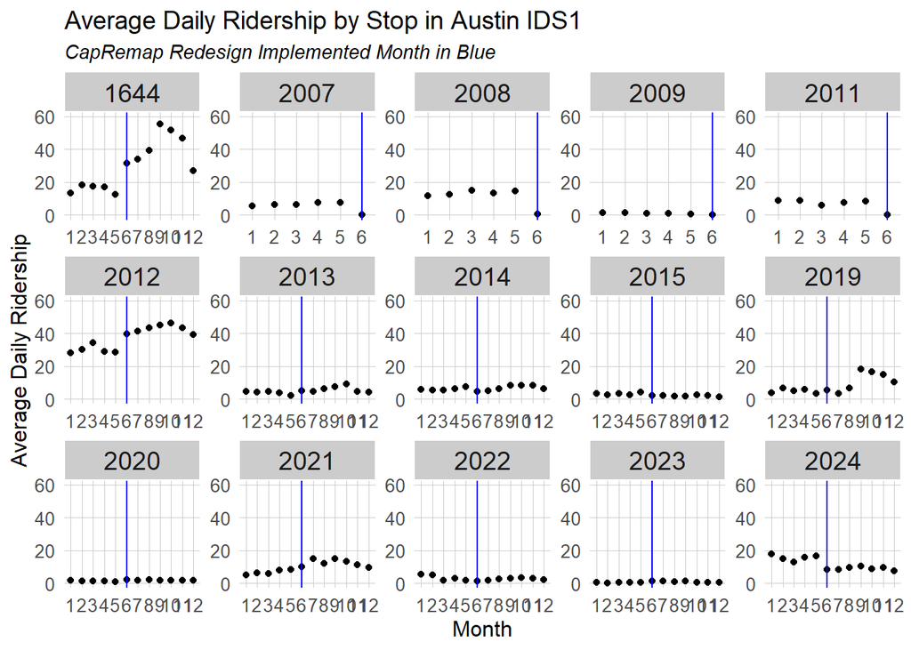

```r
plot.S1.11 <-
  as.data.frame(data.y.18.S1) %>%
  filter(STOP_ID > 1643 & STOP_ID <= 2024) %>%
  group_by(STOP_ID) %>%
    ggplot(aes(x= MONTH_ID, y=AVERAGE_ON, group = 1)) +
      geom_point() +
      plotTheme() +
      facet_wrap(~STOP_ID, scales="free", ncol=5) +
      ylim(0,60) +
      labs(title="Average Daily Ridership by Stop in Austin IDS1",
           subtitle="CapRemap Redesign Implemented Month in Blue", x="Month", y="Average Daily Ridership")+
      geom_vline(xintercept = 6, color = "blue")

plot.S1.11
```

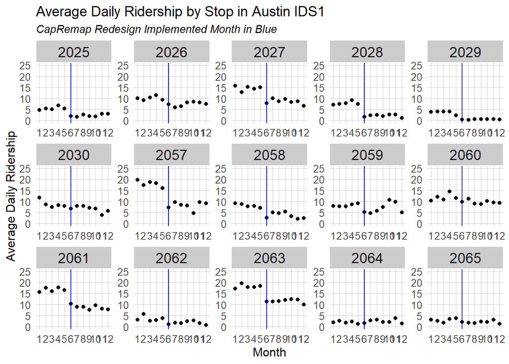

```r
plot.S1.12 <-
  as.data.frame(data.y.18.S1) %>%
  filter(STOP_ID > 2024 & STOP_ID <= 2065) %>%
  group_by(STOP_ID) %>%
    ggplot(aes(x= MONTH_ID, y=AVERAGE_ON, group = 1)) +
      geom_point() +
      plotTheme() +
      facet_wrap(~STOP_ID, scales="free", ncol=5) +
      ylim(0,25) +
      labs(title="Average Daily Ridership by Stop in Austin IDS1",
           subtitle="CapRemap Redesign Implemented Month in Blue", x="Month", y="Average Daily Ridership")+
      geom_vline(xintercept = 6, color = "blue")

plot.S1.12
```

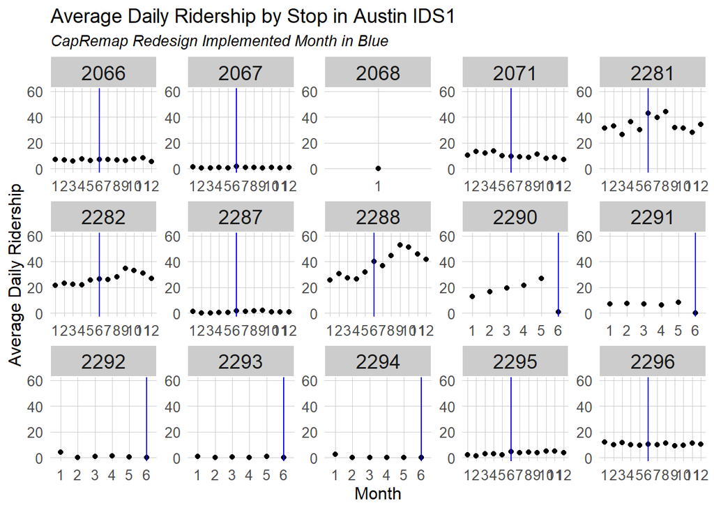

```r
plot.S1.13 <-
  as.data.frame(data.y.18.S1) %>%
  filter(STOP_ID > 2065 & STOP_ID <= 2296) %>%
  group_by(STOP_ID) %>%
    ggplot(aes(x= MONTH_ID, y=AVERAGE_ON, group = 1)) +
      geom_point() +
      plotTheme() +
      facet_wrap(~STOP_ID, scales="free", ncol=5) +
      ylim(0,60) +
      labs(title="Average Daily Ridership by Stop in Austin IDS1",
           subtitle="CapRemap Redesign Implemented Month in Blue", x="Month", y="Average Daily Ridership")+
      geom_vline(xintercept = 6, color = "blue")

plot.S1.13
```

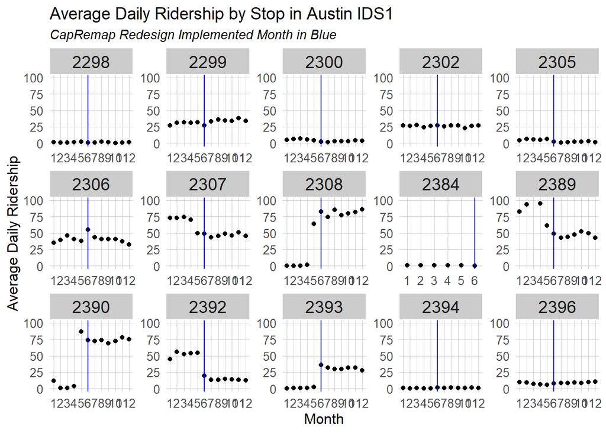

```r
plot.S1.14 <-
  as.data.frame(data.y.18.S1) %>%
  filter(STOP_ID > 2296 & STOP_ID <= 2396) %>%
  group_by(STOP_ID) %>%
    ggplot(aes(x= MONTH_ID, y=AVERAGE_ON, group = 1)) +
      geom_point() +
      plotTheme() +
      facet_wrap(~STOP_ID, scales="free", ncol=5) +
      ylim(0,100) +
      labs(title="Average Daily Ridership by Stop in Austin IDS1",
           subtitle="CapRemap Redesign Implemented Month in Blue", x="Month", y="Average Daily Ridership")+
      geom_vline(xintercept = 6, color = "blue")

plot.S1.14
```

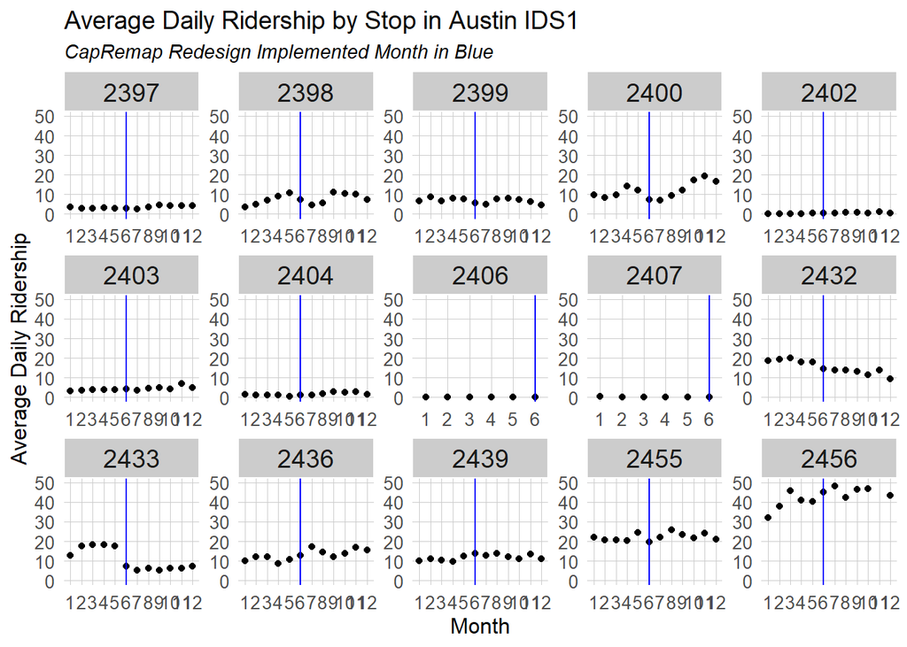

```r
plot.S1.15 <-
  as.data.frame(data.y.18.S1) %>%
  filter(STOP_ID > 2396 & STOP_ID <= 2456) %>%
  group_by(STOP_ID) %>%
    ggplot(aes(x= MONTH_ID, y=AVERAGE_ON, group = 1)) +
      geom_point() +
      plotTheme() +
      facet_wrap(~STOP_ID, scales="free", ncol=5) +
      ylim(0,50) +
      labs(title="Average Daily Ridership by Stop in Austin IDS1",
           subtitle="CapRemap Redesign Implemented Month in Blue", x="Month", y="Average Daily Ridership")+
      geom_vline(xintercept = 6, color = "blue")

plot.S1.15
```

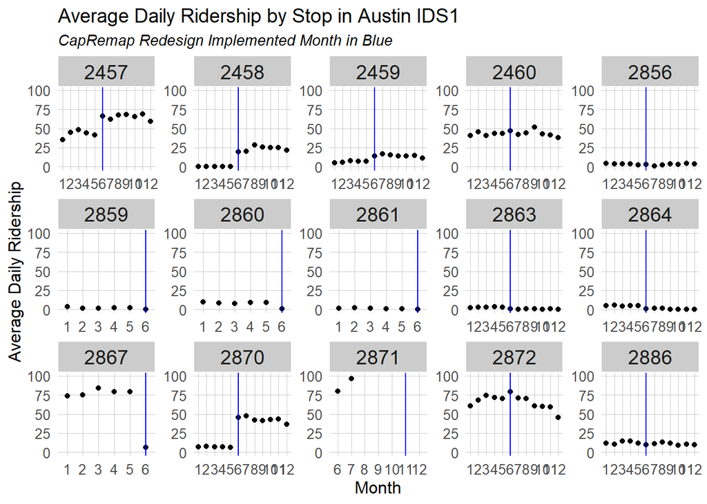

```r
plot.S1.16 <-
  as.data.frame(data.y.18.S1) %>%
  filter(STOP_ID > 2456 & STOP_ID <= 2886) %>%
  group_by(STOP_ID) %>%
    ggplot(aes(x= MONTH_ID, y=AVERAGE_ON, group = 1)) +
      geom_point() +
      plotTheme() +
      facet_wrap(~STOP_ID, scales="free", ncol=5) +
      ylim(0,100) +
      labs(title="Average Daily Ridership by Stop in Austin IDS1",
           subtitle="CapRemap Redesign Implemented Month in Blue", x="Month", y="Average Daily Ridership")+
      geom_vline(xintercept = 6, color = "blue")

plot.S1.16
```

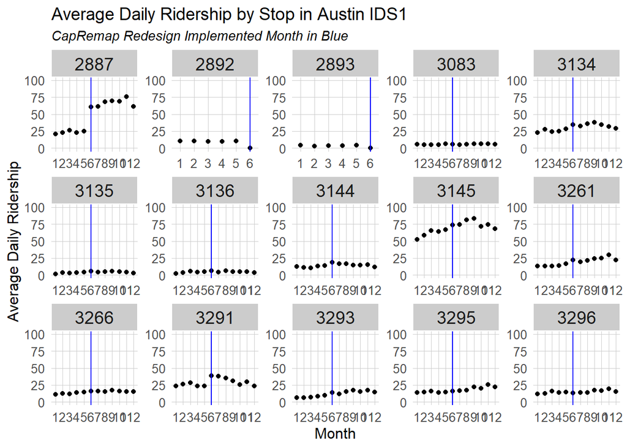

```r
plot.S1.17 <-
  as.data.frame(data.y.18.S1) %>%
  filter(STOP_ID > 2886 & STOP_ID <= 3296) %>%
  group_by(STOP_ID) %>%
    ggplot(aes(x= MONTH_ID, y=AVERAGE_ON, group = 1)) +
      geom_point() +
      plotTheme() +
      facet_wrap(~STOP_ID, scales="free", ncol=5) +
      ylim(0,100) +
      labs(title="Average Daily Ridership by Stop in Austin IDS1",
           subtitle="CapRemap Redesign Implemented Month in Blue", x="Month", y="Average Daily Ridership")+
      geom_vline(xintercept = 6, color = "blue")

plot.S1.17
```

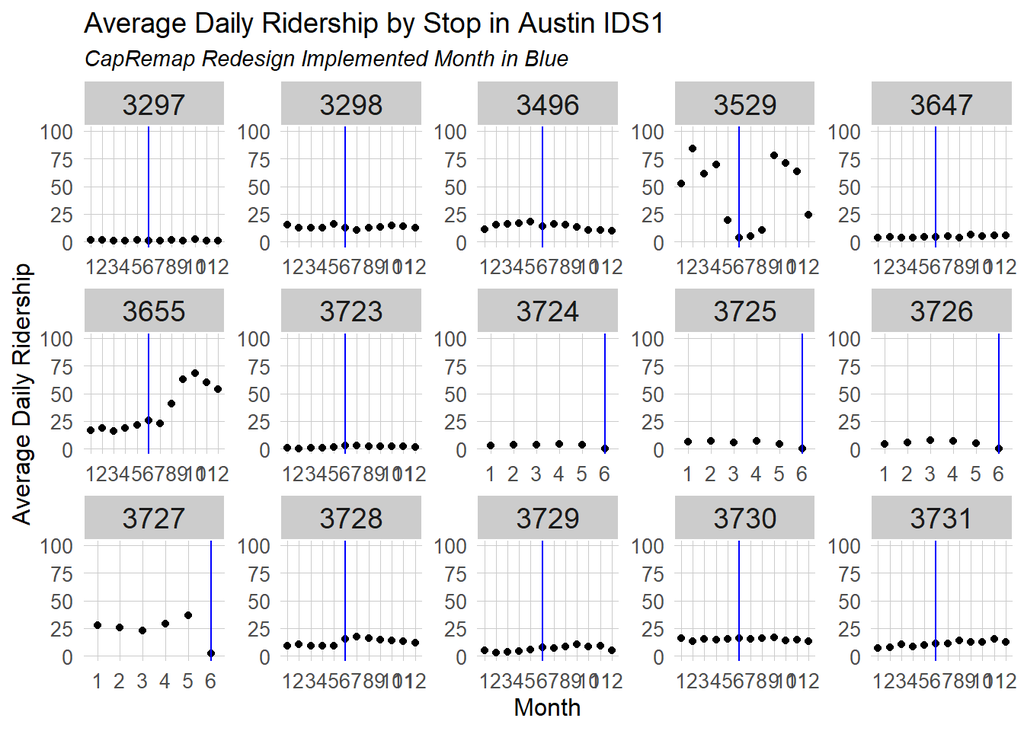

```r
plot.S1.18 <-
  as.data.frame(data.y.18.S1) %>%
  filter(STOP_ID > 3296 & STOP_ID <= 3731) %>%
  group_by(STOP_ID) %>%
    ggplot(aes(x= MONTH_ID, y=AVERAGE_ON, group = 1)) +
      geom_point() +
      plotTheme() +
      facet_wrap(~STOP_ID, scales="free", ncol=5) +
      ylim(0,100) +
      labs(title="Average Daily Ridership by Stop in Austin IDS1",
           subtitle="CapRemap Redesign Implemented Month in Blue", x="Month", y="Average Daily Ridership")+
      geom_vline(xintercept = 6, color = "blue")

plot.S1.18
```

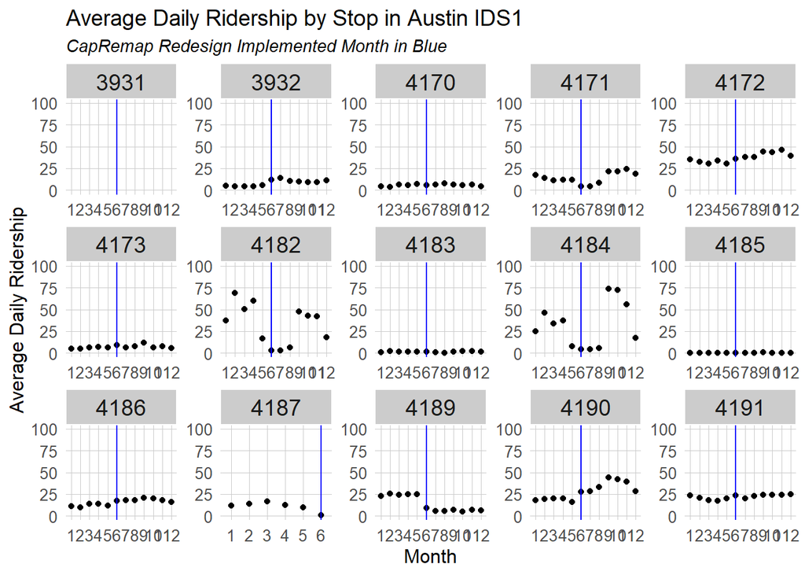

```r
plot.S1.19 <-
  as.data.frame(data.y.18.S1) %>%
  filter(STOP_ID > 3731 & STOP_ID <= 4192) %>%
  group_by(STOP_ID) %>%
    ggplot(aes(x= MONTH_ID, y=AVERAGE_ON, group = 1)) +
      geom_point() +
      plotTheme() +
      facet_wrap(~STOP_ID, scales="free", ncol=5) +
      ylim(0,100) +
      labs(title="Average Daily Ridership by Stop in Austin IDS1",
           subtitle="CapRemap Redesign Implemented Month in Blue", x="Month", y="Average Daily Ridership")+
      geom_vline(xintercept = 6, color = "blue")

plot.S1.19
```

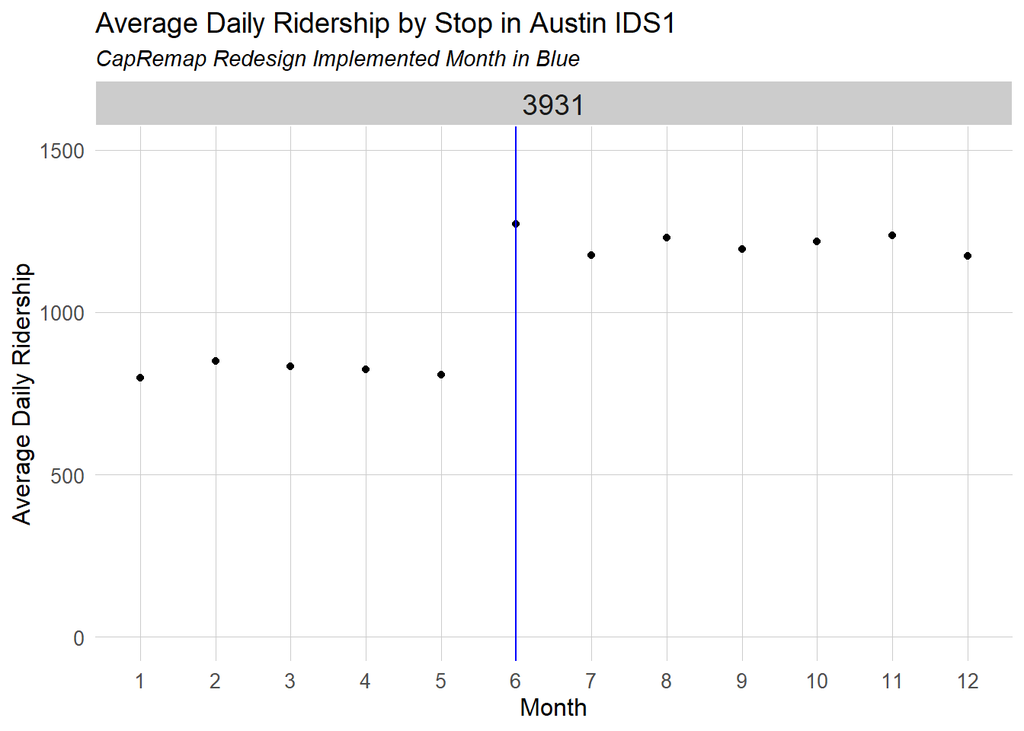

```r
plot.S1.3931 <-
  as.data.frame(data.y.18.S1) %>%
  filter(STOP_ID == 3931) %>%
  group_by(STOP_ID) %>%
    ggplot(aes(x= MONTH_ID, y=AVERAGE_ON, group = 1)) +
      geom_point() +
      plotTheme() +
      facet_wrap(~STOP_ID, scales="free", ncol=5) +
      ylim(0,1500) +
      labs(title="Average Daily Ridership by Stop in Austin IDS1",
           subtitle="CapRemap Redesign Implemented Month in Blue", x="Month", y="Average Daily Ridership")+
      geom_vline(xintercept = 6, color = "blue")

plot.S1.3931
```

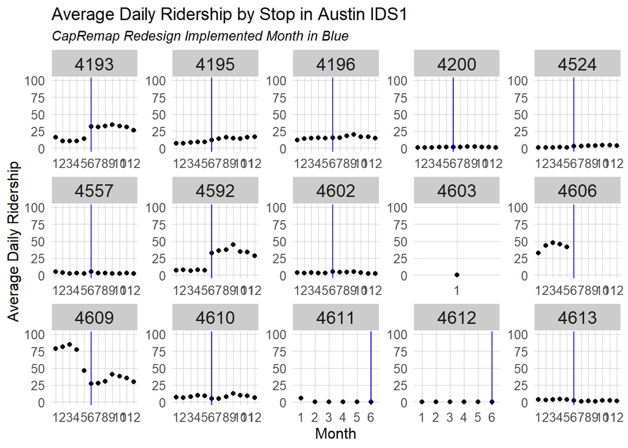

```r
plot.S1.20 <-
  as.data.frame(data.y.18.S1) %>%
  filter(STOP_ID > 4192 & STOP_ID <= 4613) %>%
  group_by(STOP_ID) %>%
    ggplot(aes(x= MONTH_ID, y=AVERAGE_ON, group = 1)) +
      geom_point() +
      plotTheme() +
      facet_wrap(~STOP_ID, scales="free", ncol=5) +
      ylim(0,100) +
      labs(title="Average Daily Ridership by Stop in Austin IDS1",
           subtitle="CapRemap Redesign Implemented Month in Blue", x="Month", y="Average Daily Ridership")+
      geom_vline(xintercept = 6, color = "blue")

plot.S1.20
```

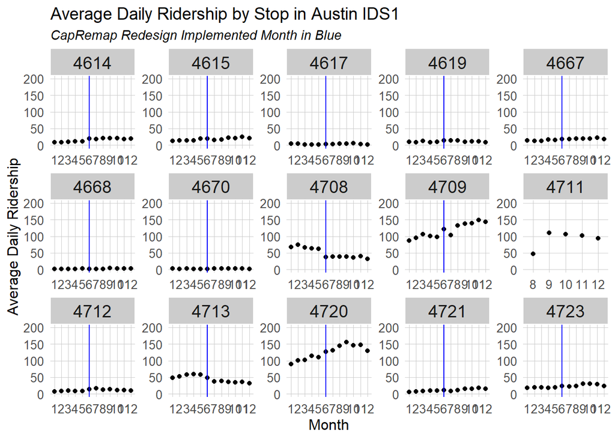

```r
plot.S1.21 <-
  as.data.frame(data.y.18.S1) %>%
  filter(STOP_ID > 4613 & STOP_ID <= 4723) %>%
  group_by(STOP_ID) %>%
    ggplot(aes(x= MONTH_ID, y=AVERAGE_ON, group = 1)) +
      geom_point() +
      plotTheme() +
      facet_wrap(~STOP_ID, scales="free", ncol=5) +
      ylim(0,200) +
      labs(title="Average Daily Ridership by Stop in Austin IDS1",
           subtitle="CapRemap Redesign Implemented Month in Blue", x="Month", y="Average Daily Ridership")+
      geom_vline(xintercept = 6, color = "blue")

plot.S1.21
```

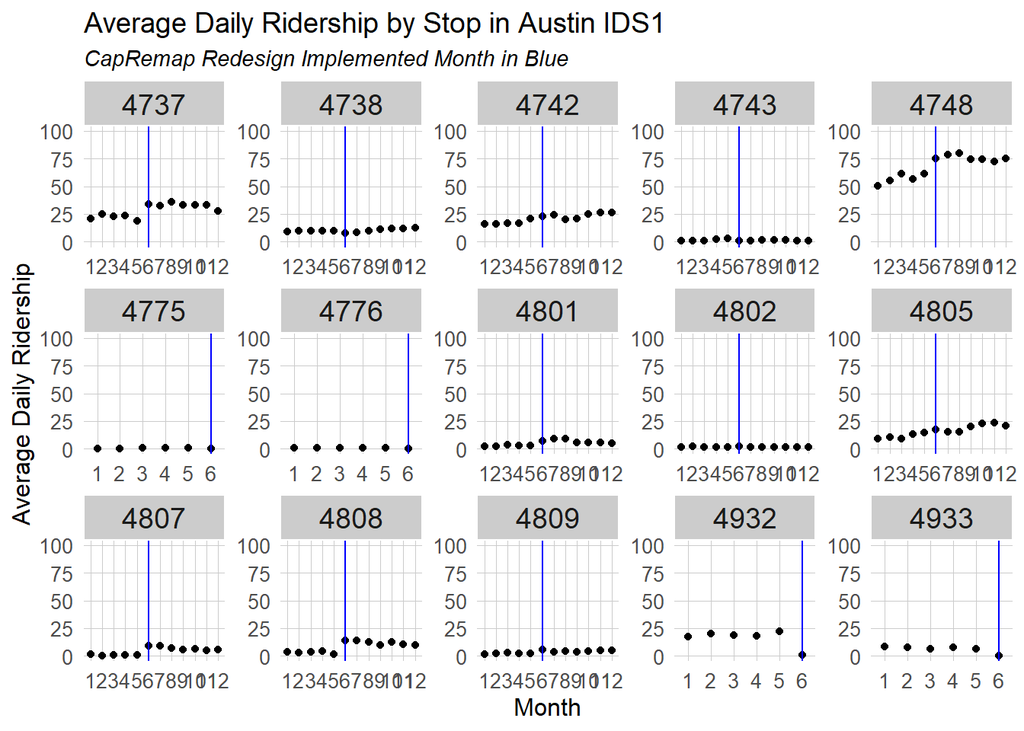

```r
plot.S1.22 <-
  as.data.frame(data.y.18.S1) %>%
  filter(STOP_ID > 4723 & STOP_ID <= 4933) %>%
  group_by(STOP_ID) %>%
    ggplot(aes(x= MONTH_ID, y=AVERAGE_ON, group = 1)) +
      geom_point() +
      plotTheme() +
      facet_wrap(~STOP_ID, scales="free", ncol=5) +
      ylim(0,100) +
      labs(title="Average Daily Ridership by Stop in Austin IDS1",
           subtitle="CapRemap Redesign Implemented Month in Blue", x="Month", y="Average Daily Ridership")+
      geom_vline(xintercept = 6, color = "blue")

plot.S1.22
```

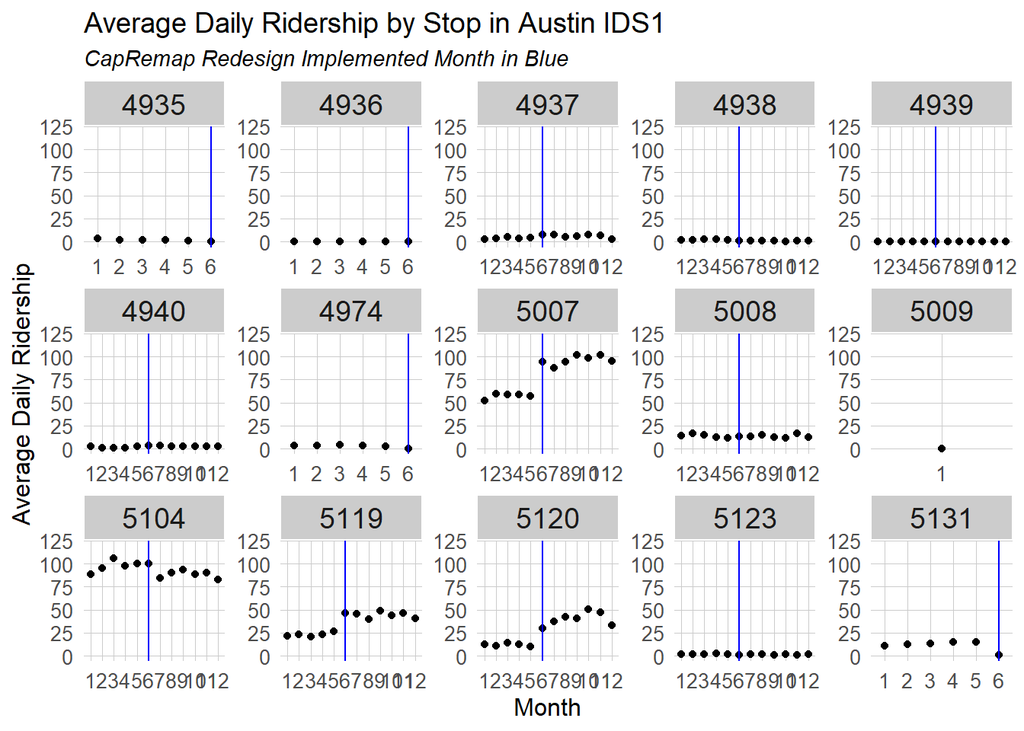

```r
plot.S1.23 <-
  as.data.frame(data.y.18.S1) %>%
  filter(STOP_ID > 4933 & STOP_ID <= 5131) %>%
  group_by(STOP_ID) %>%
    ggplot(aes(x= MONTH_ID, y=AVERAGE_ON, group = 1)) +
      geom_point() +
      plotTheme() +
      facet_wrap(~STOP_ID, scales="free", ncol=5) +
      ylim(0,120) +
      labs(title="Average Daily Ridership by Stop in Austin IDS1",
           subtitle="CapRemap Redesign Implemented Month in Blue", x="Month", y="Average Daily Ridership")+
      geom_vline(xintercept = 6, color = "blue")

plot.S1.23
```

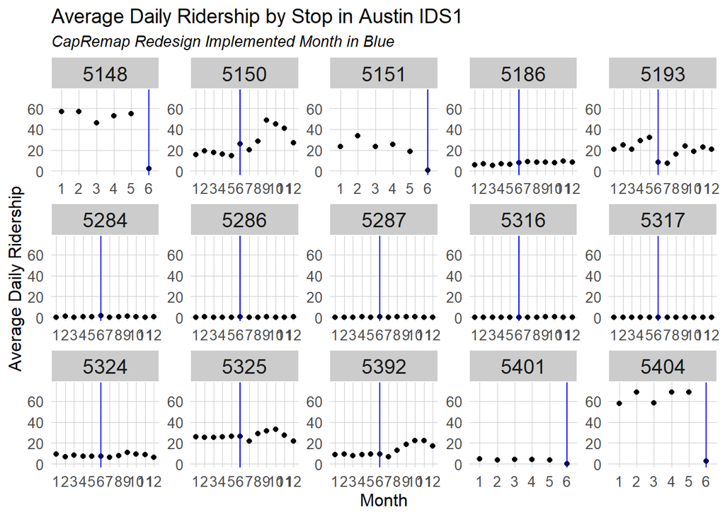

```r
plot.S1.24 <-
  as.data.frame(data.y.18.S1) %>%
  filter(STOP_ID > 5131 & STOP_ID <= 5404) %>%
  group_by(STOP_ID) %>%
    ggplot(aes(x= MONTH_ID, y=AVERAGE_ON, group = 1)) +
      geom_point() +
      plotTheme() +
      facet_wrap(~STOP_ID, scales="free", ncol=5) +
      ylim(0,75) +
      labs(title="Average Daily Ridership by Stop in Austin IDS1",
           subtitle="CapRemap Redesign Implemented Month in Blue", x="Month", y="Average Daily Ridership")+
      geom_vline(xintercept = 6, color = "blue")

plot.S1.24
```

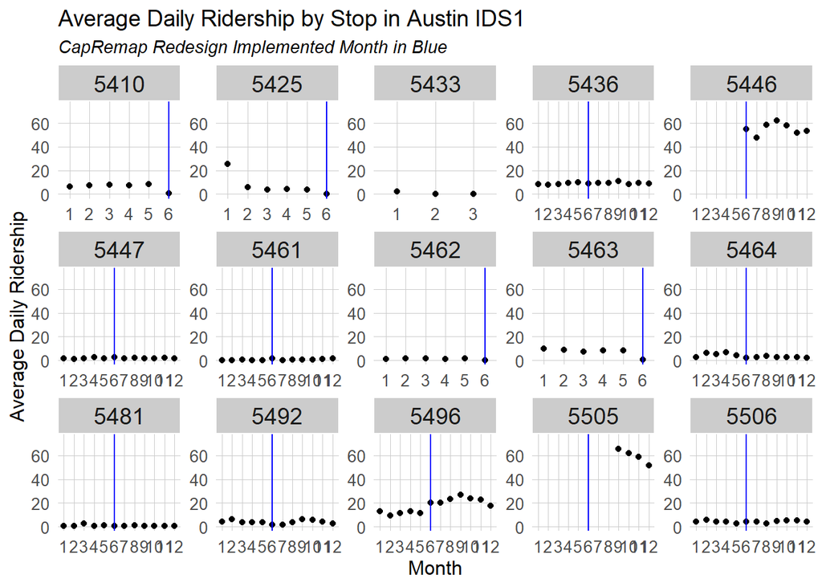

```r
plot.S1.25 <-
  as.data.frame(data.y.18.S1) %>%
  filter(STOP_ID > 5404 & STOP_ID <= 5506) %>%
  group_by(STOP_ID) %>%
    ggplot(aes(x= MONTH_ID, y=AVERAGE_ON, group = 1)) +
      geom_point() +
      plotTheme() +
      facet_wrap(~STOP_ID, scales="free", ncol=5) +
      ylim(0,75) +
      labs(title="Average Daily Ridership by Stop in Austin IDS1",
           subtitle="CapRemap Redesign Implemented Month in Blue", x="Month", y="Average Daily Ridership")+
      geom_vline(xintercept = 6, color = "blue")

plot.S1.25
```

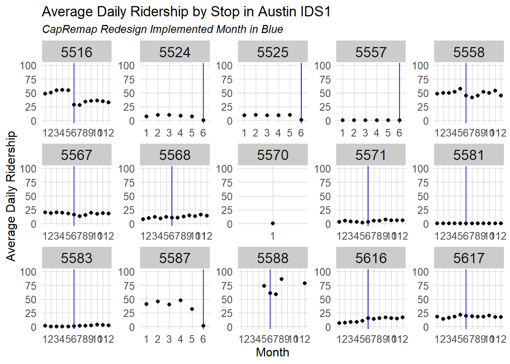

```r
plot.S1.26 <-
  as.data.frame(data.y.18.S1) %>%
  filter(STOP_ID > 5506 & STOP_ID <= 5617) %>%
  group_by(STOP_ID) %>%
    ggplot(aes(x= MONTH_ID, y=AVERAGE_ON, group = 1)) +
      geom_point() +
      plotTheme() +
      facet_wrap(~STOP_ID, scales="free", ncol=5) +
      ylim(0,100) +
      labs(title="Average Daily Ridership by Stop in Austin IDS1",
           subtitle="CapRemap Redesign Implemented Month in Blue", x="Month", y="Average Daily Ridership")+
      geom_vline(xintercept = 6, color = "blue")

plot.S1.26
```

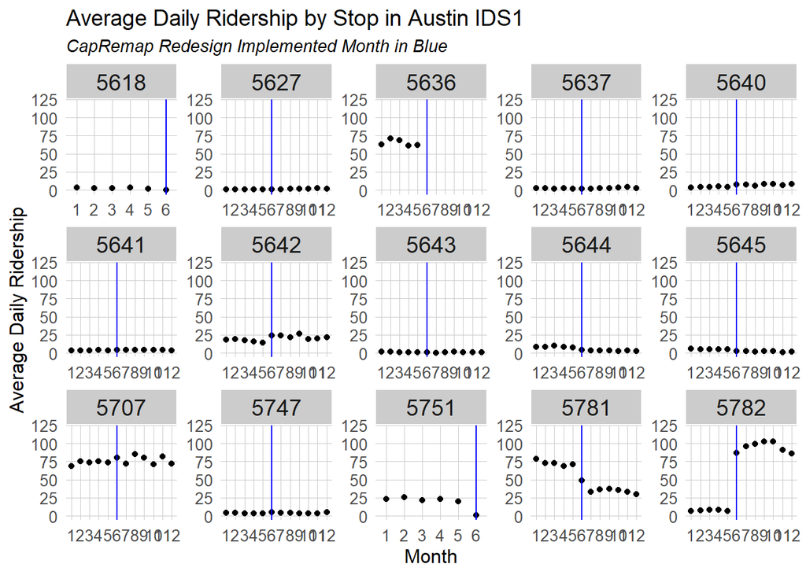

```r
plot.S1.27 <-
  as.data.frame(data.y.18.S1) %>%
  filter(STOP_ID > 5617 & STOP_ID <= 5782) %>%
  group_by(STOP_ID) %>%
    ggplot(aes(x= MONTH_ID, y=AVERAGE_ON, group = 1)) +
      geom_point() +
      plotTheme() +
      facet_wrap(~STOP_ID, scales="free", ncol=5) +
      ylim(0,120) +
      labs(title="Average Daily Ridership by Stop in Austin IDS1",
           subtitle="CapRemap Redesign Implemented Month in Blue", x="Month", y="Average Daily Ridership")+
      geom_vline(xintercept = 6, color = "blue")

plot.S1.27
```